# Spatial Planning With Zones

```r
library(spatialplanr)
set.seed(100)
```

# Overview

This code has been written to simplify the process for running a *prioritizr* analysis on a given region. It is still a work in progress so feel free to submit pull requests with new features and code improvements.

The workflow shown here was based on the [`prioritizr` introduction to zones](https://prioritizr.net/articles/management_zones_tutorial.html).

## Set user parameters

You can set a region if it is defined in `splnr_get_planningUnits`.

```r
Region <- "Coral Sea" # "Australia"
Type <- "Oceans" # "EEZ"
```

Set the shape and area of the planning unit in square kilometres.

```r
Shape <- "Hexagon" # "Shape of PUs
PU_size <- 10000 # km2
```

Choose CRS for analysis. Here we use Mollweide

```r
cCRS <-
  "+proj=moll +lon_0=0 +x_0=0 +y_0=0 +ellps=WGS84 +datum=WGS84 +units=m no_defs"
```

## Analysis Region

Start your analysis by defining your region and setting up the planning units.

Get the boundary for your chosen region.

```r
Bndry <- splnr_get_boundary(Limits = Region, Type = Type, cCRS = cCRS)
landmass <- rnaturalearth::ne_countries(
  scale = "medium",
  returnclass = "sf"
) %>%
  sf::st_transform(cCRS)
```

## Create Planning Units

```r
PUs <- splnr_get_planningUnits(Bndry, landmass, PU_size, Shape)
```

We can also use a customised `ggplot` theme that can be passed as a list to `splnr_gg_add()` and that can then be used for all plots. For example:

```r
splnr_theme <- list(
  ggplot2::theme_bw(),
  ggplot2::theme(
    legend.position = "right",
    legend.direction = "vertical",
    text = ggplot2::element_text(size = 9, colour = "black"),
    axis.text = ggplot2::element_text(size = 9, colour = "black"),
    plot.title = ggplot2::element_text(size = 9),
    axis.title = ggplot2::element_blank()
  )
)
```

## Get the features

For our example, we will use a small subset of charismatic megafauna species of the Coral Sea to inform the conservation plan. We filtered the Aquamaps (Aquamaps.org) species distribution models for our study area for the following species:

```r
Dict <- tibble::tribble(
  ~nameCommon, ~nameVariable, ~category,
  "Green sea turtle", "Chelonia_mydas", "Reptiles",
  "Loggerhead sea turtle", "Caretta_caretta", "Reptiles",
  "Hawksbill sea turtle", "Eretmochelys_imbricata", "Reptiles",
  "Olive ridley sea turtle", "Lepidochelys_olivacea", "Reptiles",
  "Saltwater crocodile", "Crocodylus_porosus", "Reptiles",
  "Humpback whale", "Megaptera_novaeangliae", "Mammals",
  "Common Minke whale", "Balaenoptera_acutorostrata",
  "Mammals",
  "Dugong", "Dugong_dugon", "Mammals",
  "Grey nurse shark", "Carcharias_taurus", "Sharks and rays",
  "Tiger shark", "Galeocerdo_cuvier", "Sharks and rays",
  "Great hammerhead shark", "Sphyrna_mokarran",
  "Sharks and rays",
  "Giant oceanic manta ray", "Mobula_birostris", "Sharks and rays",
  "Reef manta ray", "Mobula_alfredi", "Sharks and rays",
  "Whitetip reef shark", "Triaenodon_obesus", "Sharks and rays",
  "Red-footed booby", "Sula_sula", "Birds"
)
```

These species were not chosen based on their importance for this region and only represent an example for visualization purposes.

### Convert the probabilities to binary data and feature names

```r
datEx_species_bin <- spDataFiltered %>%
  splnr_apply_cutoffs(Cutoffs = 0.5)

col_name <- spDataFiltered %>%
  sf::st_drop_geometry() %>%
  dplyr::select(-"cellID") %>%
  colnames()
```

### Spatial planning including zones

So far, all steps were exactly the same as in a spatial plan that does not include zones. To have a direct comparison, we will first run a spatial plan that does not include zoning. For this, we will define targets for our features (here: 30% for all features) and create a conservation problem where we include an area-based cost in our prioritisation.

```r
target <- rep(0.3, nrow(Dict))

p1 <- prioritizr::problem(
  datEx_species_bin %>% dplyr::mutate(Cost1 = rep(1, 397)),
  col_name,
  "Cost1"
) %>%
  prioritizr::add_min_set_objective() %>%
  prioritizr::add_relative_targets(target) %>%
  prioritizr::add_binary_decisions() %>%
  prioritizr::add_default_solver(verbose = FALSE)
```

We then solve the problem and plot the solution.

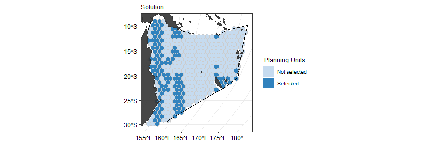

```r
s1 <- p1 %>%
  prioritizr::solve.ConservationProblem()

(ggSoln <- splnr_plot_solution(s1) +
  splnr_gg_add(PUs = PUs, Bndry = Bndry, overlay = landmass, cropOverlay = PUs, ggtheme = splnr_theme))
```

We can also have a look at how well the set target was met.

```r
s1T <- s1 %>%
  dplyr::select(tidyselect::starts_with(c("solution"))) %>%
  sf::st_drop_geometry() %>%
  tibble::as_tibble()

r1 <- prioritizr::eval_feature_representation_summary(p1, s1T)
print(r1)
```

```
#> # A tibble: 15 × 5
#>    summary feature                    total_amount absolute_held relative_held
#>    <chr>   <chr>                             <dbl>         <dbl>         <dbl>
#>  1 overall Chelonia_mydas                       22            15         0.682
#>  2 overall Caretta_caretta                      22            15         0.682
#>  3 overall Eretmochelys_imbricata               24            17         0.708
#>  4 overall Lepidochelys_olivacea                22            15         0.682
#>  5 overall Crocodylus_porosus                   21            14         0.667
#>  6 overall Megaptera_novaeangliae              388           120         0.309
#>  7 overall Balaenoptera_acutorostrata          238           112         0.471
#>  8 overall Dugong_dugon                         13             8         0.615
#>  9 overall Carcharias_taurus                    22            15         0.682
#> 10 overall Galeocerdo_cuvier                    36            29         0.806
#> 11 overall Sphyrna_mokarran                    397           120         0.302
#> 12 overall Mobula_birostris                     20            13         0.65
#> 13 overall Mobula_alfredi                       20            13         0.65
#> 14 overall Triaenodon_obesus                    25            18         0.72
#> 15 overall Sula_sula                            13             8         0.615
```

We will now look how this spatial plan needs to be extended to include multiple management zones by using `zones()`.

### Different cost layers

We first assume that we have to zones of interest that have the same set of features, but separate cost layers. For this, we need to set targets for both zones, in our case 20% for all features in the first zone and 5% of all features in the second zone.

```r
target2 <- matrix(NA, ncol = 2, nrow = nrow(Dict))
target2[, 1] <- 0.2
target2[, 2] <- 0.05
```

We then create a `zones` object where we specify the number of zones and the features in the zone. Here, we define two zones that both have the same features.

```r
z2 <- prioritizr::zones("zone 1" = col_name, "zone 2" = col_name)
```

Both zones need a specified cost and targets. We use one area-based cost and one cost layer that uses random numbers, the pre-defined targets and pass the `zones`object to the problem formulation before solving the conservation problem.

```r
p2 <- prioritizr::problem(
  datEx_species_bin %>% dplyr::mutate(
    Cost1 = rep(1, 397), # when giving sf input, we need as many cost columns as we have zones
    Cost2 = runif(n = dim(.)[[1]])
  ),
  z2,
  cost_column = c("Cost1", "Cost2")
) %>%
  prioritizr::add_min_set_objective() %>%
  prioritizr::add_relative_targets(target2) %>%
  prioritizr::add_binary_decisions() %>%
  prioritizr::add_default_solver(verbose = FALSE)

s2 <- p2 %>%
  prioritizr::solve.ConservationProblem()
```

The solution can be plotted using the function `splnr_plot_solution()` with the argument `zones` set to `TRUE`.

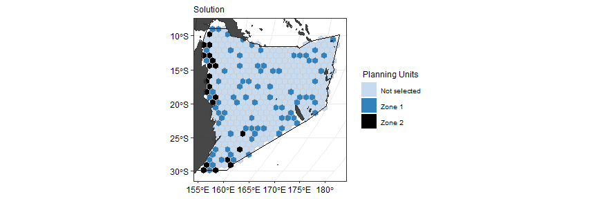

```r
(gg_s2 <- splnr_plot_solution(
  s2,
  zones = TRUE,
  colorVals = c("#c6dbef", "#3182bd", "black"),
  legendLabels = c("Not selected", "Zone 1", "Zone 2")
) +
  splnr_gg_add(
    PUs = PUs, Bndry = Bndry, overlay = landmass,
    cropOverlay = PUs, ggtheme = splnr_theme
  ))
```

We can see that we now how planning units that are not selected, and planning units that have either been selected for zone 1 or zone 2.

### Different features

When using `sf` objects with `zones()`, the input feature names to `zones()` need to have the same length and contain the same features. This means that both zones have the same features, but for some that are not of interest in that specific zone, the target is set to 0. For example, if we want to separate the example data in a zone for reptiles and another zone containing all other taxa that are not reptiles, we can specify the following targets:

```r
targets2b <- Dict %>%
  dplyr::mutate(
    targetZ1 = dplyr::if_else(category == "Reptiles", 30 / 100, 0),
    targetZ2 = dplyr::if_else(category != "Reptiles", 10 / 100, 0)
  ) %>%
  dplyr::select("targetZ1", "targetZ2") %>%
  as.matrix()
```

This sets the target for reptiles in the first zone to 30% and the rest to 0%. In the second zone, the targets for non-reptiles is 10% and for reptiles it is 0% because they are not of interest in this zone. Target data has to be given in a matrix when working with zones, so we transform the data frame to a matrix at the end.

We then define the conservation problem in the same way as above and solve it.

```r
# NOTE: when using sf input, we need as many cost columns as we have zones
p2b <- prioritizr::problem(
  datEx_species_bin %>% dplyr::mutate(
    Cost1 = rep(1, 397),
    Cost2 = runif(n = dim(.)[[1]])
  ),
  z2,
  cost_column = c("Cost1", "Cost2")
) %>%
  prioritizr::add_min_set_objective() %>%
  prioritizr::add_relative_targets(targets2b) %>%
  prioritizr::add_binary_decisions() %>%
  prioritizr::add_default_solver(verbose = FALSE)

s2b <- p2b %>%
  prioritizr::solve.ConservationProblem()
```

We can then also look at how well these targets are met in each zone (and combined).

```r
r2b <- s2b %>%
  dplyr::select(tidyselect::starts_with(c("solution"))) %>%
  sf::st_drop_geometry() %>%
  tibble::as_tibble() %>%
  prioritizr::eval_feature_representation_summary(p2b, .)
print(r2b, n = 45)
```

```
#> # A tibble: 45 × 5
#>    summary feature total_amount absolute_held relative_held
#>    <chr>   <chr>          <dbl>         <dbl>         <dbl>
#>  1 overall 1                 44            11       0.25
#>  2 overall 2                 44            11       0.25
#>  3 overall 3                 48            11       0.229
#>  4 overall 4                 44            11       0.25
#>  5 overall 5                 42            10       0.238
#>  6 overall 6                776            42       0.0541
#>  7 overall 7                476            26       0.0546
#>  8 overall 8                 26             5       0.192
#>  9 overall 9                 44            11       0.25
#> 10 overall 10                72            13       0.181
#> 11 overall 11               794            48       0.0605
#> 12 overall 12                40            10       0.25
```

[output cut: 33 more lines]

We can see that each of the 15 features is listed (as a number) for an overall summary, summary for zone 1 and summary for zone 2. When looking at the `relative_held` column in the `tibble`, we observe that in the summary of zone 1 (from row 16 onwards), some features have >30% targets met, whereas others (such as feature 6 and 7) have a very low percentage of suitable habitat within selected planning units. We can extract the common names of those two features:

```r
Dict[[1]][6]
```

```
#> [1] "Humpback whale"
```

```r
Dict[[1]][7]
```

```
#> [1] "Common Minke whale"
```

They are both marine mammals and thus had a target of 0% in zone 1 that was the reptile-specific zone. The percentage of selected suitable habitat is not 0% despite the target of 0 because a proportion of suitable habitat of mammals was selected incidentally when selecting planning units in this zone by meeting the targets for reptiles. The same applies for zone 2. We can also plot the final solution again:

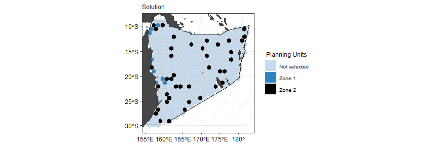

```r
(gg_s2b <- splnr_plot_solution(
  s2b,
  zones = TRUE,
  colorVals = c("#c6dbef", "#3182bd", "black"),
  legendLabels = c("Not selected", "Zone 1", "Zone 2")
) +
  splnr_gg_add(
    PUs = PUs, Bndry = Bndry, overlay = landmass,
    cropOverlay = PUs, ggtheme = splnr_theme
  ))
```

### Boundary penalty

Similar to “normal” priritisations, zones also allows including a boundary penalty. There are several options how this can be done within zones or between zones.

#### Within the same zone

```r
zm1 <- diag(2)
print(zm1)
```

```
#>      [,1] [,2]
#> [1,]    1    0
#> [2,]    0    1
```

The zeros in this matrix denote that there is no penalty between zones, whereas ones introduce a boundary penalty when we define the conservation problem. Here, we only introduce penalties within zone 1 AND zone 2 respectively.

```r
p3 <- prioritizr::problem(
  datEx_species_bin %>% dplyr::mutate(
    Cost1 = rep(1, 397), # when giving sf input, we need as many cost columns as we have zones
    Cost2 = runif(n = dim(.)[[1]])
  ),
  z2,
  cost_column = c("Cost1", "Cost2")
) %>%
  prioritizr::add_min_set_objective() %>%
  prioritizr::add_boundary_penalties(0.5, zone = zm1) %>%
  prioritizr::add_relative_targets(target2) %>%
  prioritizr::add_binary_decisions() %>%
  prioritizr::add_default_solver(time_limit = 10, verbose = FALSE)

s3 <- p3 %>%
  prioritizr::solve.ConservationProblem()
```

With `add_boundary_penalties()` we set a penalty of 0.5 between the zones we defined in `zm1`. For the purpose of this example, we also set a 10 second time limit for the prioritisation. The results show less fragmentation than in the previous solution without penalties:

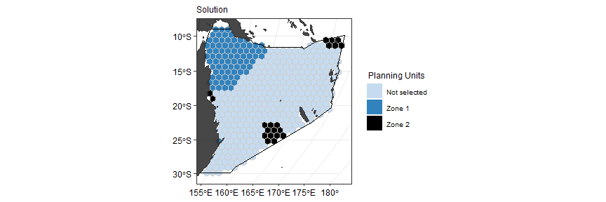

```r
(gg_s3 <- splnr_plot_solution(
  s3,
  zones = TRUE,
  colorVals = c("#c6dbef", "#3182bd", "black"),
  legendLabels = c("Not selected", "Zone 1", "Zone 2")
) +
  splnr_gg_add(
    PUs = PUs, Bndry = Bndry, overlay = landmass,
    cropOverlay = PUs, ggtheme = splnr_theme
  ))
```

A boundary penalty can also be introduced to only one zone:

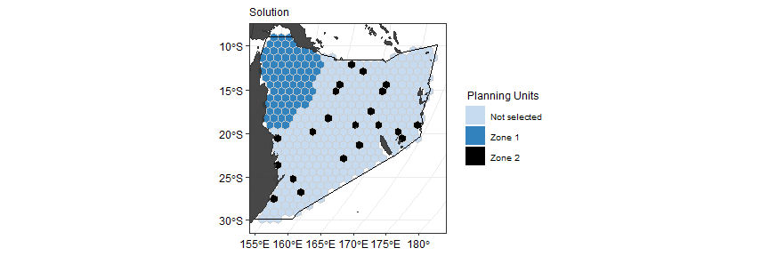

```r
zm2 <- zm1
zm2[2, 2] <- 0

# NOTE: When using sf input, we need as many cost columns as we have zones
p4 <- prioritizr::problem(
  datEx_species_bin %>% dplyr::mutate(
    Cost1 = rep(1, 397),
    Cost2 = runif(n = dim(.)[[1]])
  ),
  z2,
  cost_column = c("Cost1", "Cost2")
) %>%
  prioritizr::add_min_set_objective() %>%
  prioritizr::add_boundary_penalties(0.5, zone = zm2) %>%
  prioritizr::add_relative_targets(target2) %>%
  prioritizr::add_binary_decisions() %>%
  prioritizr::add_default_solver(time_limit = 10, verbose = FALSE)

s4 <- p4 %>%
  prioritizr::solve.ConservationProblem()

(gg_s4 <- splnr_plot_solution(
  s4,
  zones = TRUE,
  colorVals = c("#c6dbef", "#3182bd", "black"),
  legendLabels = c("Not selected", "Zone 1", "Zone 2")
) +
  splnr_gg_add(
    PUs = PUs, Bndry = Bndry, overlay = landmass,
    cropOverlay = PUs, ggtheme = splnr_theme
  ))
```

#### Across zones

Similarly, penalties can be applied between zones if specified in the problem.

```r
zm3 <- matrix(1, ncol = 2, nrow = 2)
print(zm3)
```

```
#>      [,1] [,2]
#> [1,]    1    1
#> [2,]    1    1
```

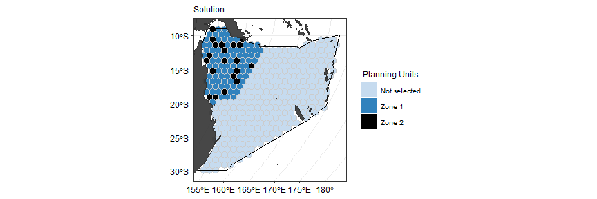

```r
p5 <- prioritizr::problem(
  datEx_species_bin %>% dplyr::mutate(
    Cost1 = rep(1, 397), # when giving sf input, we need as many cost columns as we have zones
    Cost2 = runif(n = dim(.)[[1]])
  ),
  z2,
  cost_column = c("Cost1", "Cost2")
) %>%
  prioritizr::add_min_set_objective() %>%
  prioritizr::add_boundary_penalties(0.5, zone = zm3) %>%
  prioritizr::add_relative_targets(target2) %>%
  prioritizr::add_binary_decisions() %>%
  prioritizr::add_default_solver(time_limit = 10, verbose = FALSE)

s5 <- p5 %>%
  prioritizr::solve.ConservationProblem()

(gg_s5 <- splnr_plot_solution(
  s5,
  zones = TRUE,
  colorVals = c("#c6dbef", "#3182bd", "black"),
  legendLabels = c("Not selected", "Zone 1", "Zone 2")
) +
  splnr_gg_add(
    PUs = PUs, Bndry = Bndry, overlay = landmass,
    cropOverlay = PUs, ggtheme = splnr_theme
  ))
```

### Adding constraints

Another addition often used in conservation planning are constraints. We often lock in or lock out areas of interest for various reasons. In this example, we will lock in already existing MPAs in one of the zones.

When using zones with constraints, we use the `prioritizr` function `add_manual_locked_constraints()` that requires the input to be in a specific format, so we first prepare the MPA data.

```r
mpas <- MPAsCoralSea %>%
  dplyr::mutate(zone = "zone 1") %>%
  dplyr::rename(
    pu = cellID,
    status = wdpa
  ) %>%
  sf::st_drop_geometry() %>%
  tibble::tibble() %>%
  dplyr::filter(status == 1)
```

We need to specify which zone the constraint should be applied to, give information on the planning unit identifier, rename the column of interest to “status” and filter out only the planning units that should be locked in.

```r
# NOTE: When using sf input, we need as many cost columns as we have zones
p6 <- prioritizr::problem(
  datEx_species_bin %>% dplyr::mutate(
    Cost1 = rep(1, 397),
    Cost2 = runif(n = dim(.)[[1]])
  ),
  z2,
  cost_column = c("Cost1", "Cost2")
) %>%
  prioritizr::add_min_set_objective() %>%
  prioritizr::add_manual_locked_constraints(mpas) %>%
  prioritizr::add_relative_targets(target2) %>%
  prioritizr::add_binary_decisions() %>%
  prioritizr::add_default_solver(time_limit = 10, verbose = FALSE)

s6 <- p6 %>%
  prioritizr::solve.ConservationProblem()
```

The results can the be visualized again:

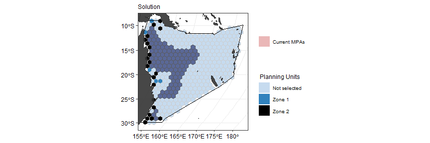

```r
(gg_s6 <- splnr_plot_solution(
  s6,
  zones = TRUE,
  colorVals = c("#c6dbef", "#3182bd", "black"),
  legendLabels = c("Not selected", "Zone 1", "Zone 2")
) +
  splnr_gg_add(
    PUs = PUs, Bndry = Bndry,
    lockedInAreas = MPAsCoralSea, colInterest = MPAsCoralSea$wdpa,
    Type = "Full", colorLI = "red", alphaLI = 0.2, overlay = landmass,
    cropOverlay = PUs, ggtheme = splnr_theme, labelL = "Current MPAs"
  ))
```

### Objective functions

So far we have only used the minimum set objective function to meet all conservation targets whilst minimizing the cost. However, this is not the only objective function available in `prioritizr`. For example when maximising mangrove ecosystem services, we employed a minimum shortfall objective function instead [(Dabalà et al 2022)](https://www.researchgate.net/publication/363818810_Priority_areas_to_protect_mangroves_and_maximise_ecosystem_services). For this objective function, we allocate a budget that cannot be exceeded (for example area >30%) whilst still trying to minimise the cost and meeting the targets - but not all targets might be met (shortfall).

Zones also works with objective functions other than the minimum set objective function.

```r
# NOTE: When using sf input, we need as many cost columns as we have zones
p7 <- prioritizr::problem(
  datEx_species_bin %>% dplyr::mutate(
    Cost1 = rep(1, 397),
    Cost2 = runif(n = dim(.)[[1]])
  ),
  z2,
  cost_column = c("Cost1", "Cost2")
) %>%
  prioritizr::add_min_shortfall_objective(c(8, 0.3)) %>%
  prioritizr::add_relative_targets(target2) %>%
  prioritizr::add_binary_decisions() %>%
  prioritizr::add_default_solver(time_limit = 10, verbose = FALSE)
```

Here we apply `add_min_shortfall_objective()` and provide to separate budgets for the two zones (8 and 0.3). We can visualize the output again after solving the conservation problem.

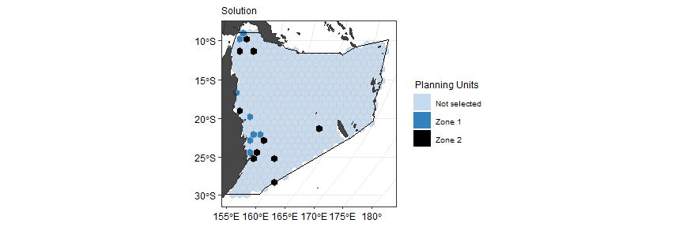

```r
s7 <- p7 %>%
  prioritizr::solve.ConservationProblem()

(gg_s7 <- splnr_plot_solution(
  s7,
  zones = TRUE,
  colorVals = c("#c6dbef", "#3182bd", "black"),
  legendLabels = c("Not selected", "Zone 1", "Zone 2")
) +
  splnr_gg_add(
    PUs = PUs, Bndry = Bndry, overlay = landmass,
    cropOverlay = PUs, ggtheme = splnr_theme
  ))
```

### Alternative: linear constraints

Sometimes a spatial plan might be needed that requires minimising several costs at once, but a binary output (inside the protected area/outside the protected area) is sufficient. In this case, using linear constraints instead of zones might be a simpler and more time-efficient way forward.

Linear constraints make sure that all planning units in the selected area meet the criteria given in the constraint. For example, when using an area-based cost (lowest number of planning units to meet the target), we might also simultaneously want to minimise the cost to fisheries and keep it below a certain threshold. Inversely, we might want to minimise the cost to fisheries but also not select more than 30% of the area.

In our example, we fill first define our targets and a random cost layer with values ranging from 0 to 1.

```r
target8 <- rep(0.3, nrow(Dict))

set.seed <- 10 # Add seed so the problem below solves each time

costRandom <- datEx_species_bin %>%
  dplyr::mutate(CostR = runif(n = dim(.)[[1]])) %>%
  dplyr::select("CostR")
```

We then define and solve our conservation problem:

```r
p8 <- prioritizr::problem(
  datEx_species_bin %>% dplyr::mutate(Cost1 = rep(1, 397)),
  col_name,
  "Cost1"
) %>%
  prioritizr::add_min_set_objective() %>%
  prioritizr::add_relative_targets(target8) %>%
  prioritizr::add_linear_constraints(sum(costRandom$CostR) * 0.1,
    sense = "<=", costRandom$CostR
  ) %>%
  prioritizr::add_binary_decisions() %>%
  prioritizr::add_default_solver(verbose = FALSE)

s8 <- p8 %>%
  prioritizr::solve.ConservationProblem()
```

Based on the problem definition, we want to meet the targets for our biodiversity features whilst selecting the lowest number of planning units possible. However, the solution also depends on the threshold of the linear constraint specified with `add_linear_constraints()`in the problem. Specifically, the planning units selected in the solution can not exceed 10% of the total cost of all planning units in `costRandom$CostR`.

We can visualise the solution again:

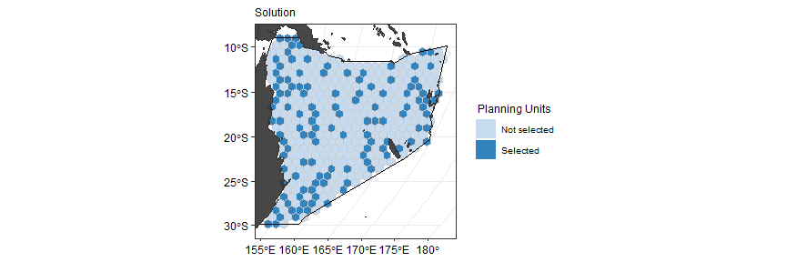

```r
(gg_s8 <- splnr_plot_solution(s8) +
  splnr_gg_add(PUs = PUs, Bndry = Bndry, overlay = landmass, cropOverlay = PUs, ggtheme = splnr_theme))
```

**NOTE:** We can also use multiple linear constraints in the same plan, however, this might require a normalization of the input data to have the constraints in comparable units, and a careful tuning of the thresholds, so `prioritizr` is still able to solve the problem.

### Common targets across zones

Sometimes it might be required to meet a (common) conservation target across multiple zones, so several zones contribute to reaching the target. For this, we need to define a target across zones (here: 30% of all features across zones):

```r
targetAcross <- dplyr::tibble(
  feature = col_name,
  zone = list(c("zone1", "zone2"))[rep(1, length(col_name))],
  target = rep(0.3, length(col_name)),
  type = rep("relative", length(col_name))
)
```

We then need to bring our data in a specific format that requires us to have an individual column for a feature in a specific zone, so if we have `spp1` and two zones (`zone1` an `zone2`), then we have to have two separate columns of the input data: `spp1_zone1` and `spp1_zone2`. The species names and zone names have to be exactly those specified in the `zones()` object and have to separated by a `_`.

```r
datSpecZone1 <- datEx_species_bin %>%
  sf::st_drop_geometry() %>%
  dplyr::rename_at(dplyr::vars(-cellID), ~ paste0(.x, "_zone1"))

featuresZone1 <- datSpecZone1 %>%
  dplyr::select(-"cellID") %>%
  colnames()

datSpecZone2 <- datEx_species_bin %>%
  sf::st_drop_geometry() %>%
  dplyr::rename_at(dplyr::vars(-cellID), ~ paste0(.x, "_zone2"))

featuresZone2 <- datSpecZone2 %>%
  dplyr::select(-"cellID") %>%
  colnames()
```

We also extract the new feature names and then create the `zones` object, before joining the two newly created data frames to an file that will be used in the prioriztisation.

```r
z10 <- prioritizr::zones(
  featuresZone1,
  featuresZone2,
  zone_names = c("zone1", "zone2"),
  feature_names = col_name
)

out_sf <- datSpecZone1 %>%
  dplyr::left_join(datSpecZone2, by = "cellID") %>%
  dplyr::mutate(geometry = datEx_species_bin$geometry) %>%
  sf::st_as_sf() %>%
  dplyr::mutate(
    Cost1 = runif(n = dim(.)[[1]]) * 100,
    Cost2 = runif(n = dim(.)[[1]]) * 300
  )
```

We can see here that we defined to (random) cost layers with the cost layer for `zone2` being three times as costly as for `zone1`.

```r
p10 <- prioritizr::problem(out_sf,
  z10,
  cost_column = c("Cost1", "Cost2")
) %>%
  prioritizr::add_min_set_objective() %>%
  prioritizr::add_manual_targets(targetAcross) %>%
  prioritizr::add_binary_decisions() %>%
  prioritizr::add_default_solver(verbose = FALSE)

s10 <- p10 %>%
  prioritizr::solve.ConservationProblem()
```

After setting up and solving the conservation problem, we can have a look at the resulting solution and how well the targets are met.

```r
s10F <- s10 %>%
  dplyr::select(tidyselect::starts_with(c("solution"))) %>%
  sf::st_drop_geometry() %>%
  tibble::as_tibble()

r10 <- prioritizr::eval_feature_representation_summary(p10, s10F)
print(r10)
```

```
#> # A tibble: 45 × 5
#>    summary feature                    total_amount absolute_held relative_held
#>    <chr>   <chr>                             <dbl>         <dbl>         <dbl>
#>  1 overall Chelonia_mydas                       44            18         0.409
#>  2 overall Caretta_caretta                      44            18         0.409
#>  3 overall Eretmochelys_imbricata               48            19         0.396
#>  4 overall Lepidochelys_olivacea                44            18         0.409
#>  5 overall Crocodylus_porosus                   42            17         0.405
#>  6 overall Megaptera_novaeangliae              776           233         0.300
#>  7 overall Balaenoptera_acutorostrata          476           159         0.334
#>  8 overall Dugong_dugon                         26            11         0.423
#>  9 overall Carcharias_taurus                    44            18         0.409
#> 10 overall Galeocerdo_cuvier                    72            31         0.431
#> # ℹ 35 more rows
```

The overall summary shows that every feature’s suitable habitat was represented by at least 30% which was the combined target we had set. However, we can see that features from `zone1` were a lot more frequently selected than `zone2` because `zone2` is three times as costly.

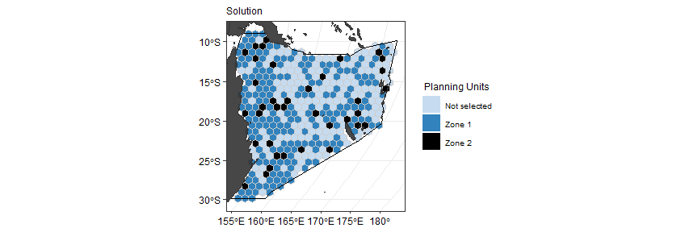

```r
(gg_s10 <- splnr_plot_solution(s10,
  zones = TRUE,
  colorVals = c("#c6dbef", "#3182bd", "black"),
  legendLabels = c("Not selected", "Zone 1", "Zone 2")
) +
  splnr_gg_add(
    PUs = PUs, Bndry = Bndry, overlay = landmass,
    cropOverlay = PUs, ggtheme = splnr_theme
  ))
```

The plot also reflects the observation above that PUs were more frequently selected in `zone1`. What if we wanted to constrain this, so that `zone1` is less often selected and `zone2` more often?

### Targets across zones with linear constraints

We can include linear constraints for `zone1` above, so that its area does not exceed 30% of the whole area. For this we need to create a matrix that contains the data for the constraint that we want to include. Although we only want to put the linear constraint on `zone1`, `prioritizr` still requires the matrix to have as many columns as there are zones. Thus, we set the area cost to `1` for `zone1` where we want to have the constraint and to all `0` in `zone2` where we do not want to introduce a linear constraint.

```r
CostArea <- out_sf %>%
  dplyr::mutate(
    areaCostZone1 = rep(1, 397),
    areaCostZone2 = rep(0, 397)
  ) %>%
  sf::st_drop_geometry() %>%
  dplyr::select("areaCostZone1", "areaCostZone2") %>%
  as.matrix()
```

We then define the conservation problem and add a linear constraint for 30% of the area.

```r
p11 <- prioritizr::problem(out_sf,
  z10,
  cost_column = c("Cost1", "Cost2")
) %>%
  prioritizr::add_min_set_objective() %>%
  prioritizr::add_linear_constraints(sum(CostArea[, 1]) * 0.3,
    sense = "<=", CostArea
  ) %>%
  prioritizr::add_manual_targets(targetAcross) %>%
  prioritizr::add_binary_decisions() %>%
  prioritizr::add_default_solver(verbose = FALSE)

s11 <- p11 %>%
  prioritizr::solve.ConservationProblem()
```

```r
s11F <- s11 %>%
  dplyr::select(tidyselect::starts_with(c("solution"))) %>%
  sf::st_drop_geometry() %>%
  tibble::as_tibble()

r11 <- prioritizr::eval_feature_representation_summary(p11, s11F)
print(r11)
```

```
#> # A tibble: 45 × 5
#>    summary feature                    total_amount absolute_held relative_held
#>    <chr>   <chr>                             <dbl>         <dbl>         <dbl>
#>  1 overall Chelonia_mydas                       44            14         0.318
#>  2 overall Caretta_caretta                      44            14         0.318
#>  3 overall Eretmochelys_imbricata               48            15         0.312
#>  4 overall Lepidochelys_olivacea                44            14         0.318
#>  5 overall Crocodylus_porosus                   42            14         0.333
#>  6 overall Megaptera_novaeangliae              776           233         0.300
#>  7 overall Balaenoptera_acutorostrata          476           143         0.300
#>  8 overall Dugong_dugon                         26             9         0.346
#>  9 overall Carcharias_taurus                    44            14         0.318
#> 10 overall Galeocerdo_cuvier                    72            24         0.333
#> # ℹ 35 more rows
```

The selected planning units are now more equally distributed across zones, which is also observable in the plot:

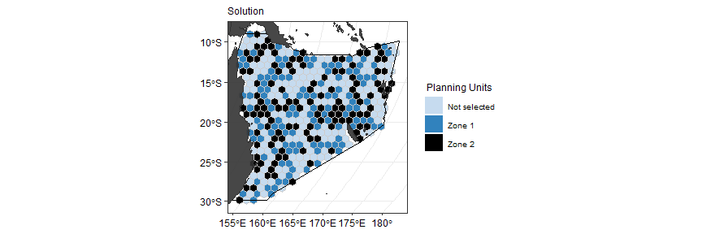

```r
(gg_s11 <- splnr_plot_solution(
  s11,
  zones = TRUE,
  colorVals = c("#c6dbef", "#3182bd", "black"),
  legendLabels = c("Not selected", "Zone 1", "Zone 2")
) +
  splnr_gg_add(
    PUs = PUs, Bndry = Bndry, overlay = landmass,
    cropOverlay = PUs, ggtheme = splnr_theme
  ))
```

However, we also expect the cost for the spatial plan to be higher than the previous one.

### Targets across some (but not all) zones

```r
targetAcrossSome <- Dict %>%
  dplyr::mutate(
    target = dplyr::case_when(
      category == "Reptiles" ~ 30 / 100,
      category == "Mammals" ~ 10 / 100,
      category == "Sharks and rays" ~ 5 / 100,
      TRUE ~ 0
    ),
    zone = dplyr::case_when(
      category == "Reptiles" ~ list(c("zone1", "zone2")),
      category == "Mammals" ~ list("zone2"),
      category == "Sharks and rays" ~ list("zone3"),
      TRUE ~ list(c("zone1", "zone2", "zone3"))
    ),
    type = rep("relative", length(col_name))
  ) %>%
  dplyr::rename(feature = "nameVariable") %>%
  dplyr::select(-"category", -"nameCommon")
```

We then create a zones object for three different zones:

```r
datSpecZone1 <- datEx_species_bin %>%
  sf::st_drop_geometry() %>%
  dplyr::rename_at(dplyr::vars(-cellID), ~ paste0(.x, "_zone1"))

featuresZone1 <- datSpecZone1 %>%
  dplyr::select(-"cellID") %>%
  colnames()

datSpecZone2 <- datEx_species_bin %>%
  sf::st_drop_geometry() %>%
  dplyr::rename_at(dplyr::vars(-cellID), ~ paste0(.x, "_zone2"))

featuresZone2 <- datSpecZone2 %>%
  dplyr::select(-"cellID") %>%
  colnames()

datSpecZone3 <- datEx_species_bin %>%
  sf::st_drop_geometry() %>%
  dplyr::rename_at(dplyr::vars(-cellID), ~ paste0(.x, "_zone3"))

featuresZone3 <- datSpecZone3 %>%
  dplyr::select(-"cellID") %>%
  colnames()

z12 <- prioritizr::zones(
  featuresZone1,
  featuresZone2,
  featuresZone3,
  zone_names = c("zone1", "zone2", "zone3"),
  feature_names = col_name
)
```

We then create a joint `sf` object of all zones and their respective costs.

```r
# NOTE: When using sf input, we need as many cost columns as we have zones
out_sf <- datSpecZone1 %>%
  dplyr::left_join(datSpecZone2, by = "cellID") %>%
  dplyr::left_join(datSpecZone3, by = "cellID") %>%
  dplyr::mutate(geometry = datEx_species_bin$geometry) %>%
  sf::st_as_sf() %>%
  dplyr::mutate(
    Cost1 = runif(n = dim(.)[[1]]) * 100,
    Cost2 = runif(n = dim(.)[[1]]) * 300,
    Cost3 = runif(n = dim(.)[[1]]) * 200
  )
```

```r
p12 <- prioritizr::problem(out_sf,
  z12,
  cost_column = c("Cost1", "Cost2", "Cost3")
) %>%
  prioritizr::add_min_set_objective() %>%
  prioritizr::add_manual_targets(targetAcrossSome) %>%
  prioritizr::add_binary_decisions() %>%
  prioritizr::add_default_solver(verbose = FALSE)

s12 <- p12 %>%
  prioritizr::solve.ConservationProblem()
```

```r
s12F <- s12 %>%
  dplyr::select(tidyselect::starts_with(c("solution"))) %>%
  sf::st_drop_geometry() %>%
  tibble::as_tibble()

r12 <- prioritizr::eval_feature_representation_summary(p12, s12F)
print(r12)
```

```
#> # A tibble: 60 × 5
#>    summary feature                    total_amount absolute_held relative_held
#>    <chr>   <chr>                             <dbl>         <dbl>         <dbl>
#>  1 overall Chelonia_mydas                       66            16        0.242
#>  2 overall Caretta_caretta                      66            16        0.242
#>  3 overall Eretmochelys_imbricata               72            17        0.236
#>  4 overall Lepidochelys_olivacea                66            16        0.242
#>  5 overall Crocodylus_porosus                   63            16        0.254
#>  6 overall Megaptera_novaeangliae             1164            64        0.0550
#>  7 overall Balaenoptera_acutorostrata          714            44        0.0616
#>  8 overall Dugong_dugon                         39             8        0.205
#>  9 overall Carcharias_taurus                    66            16        0.242
#> 10 overall Galeocerdo_cuvier                   108            19        0.176
#> # ℹ 50 more rows
```

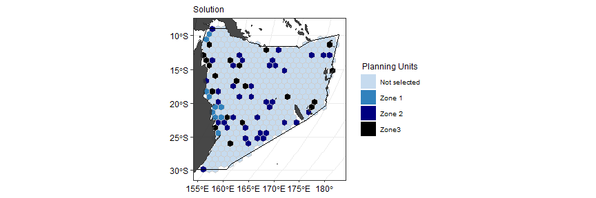

```r
(gg_s12 <- splnr_plot_solution(
  s12,
  zones = TRUE,
  colorVals = c("#c6dbef", "#3182bd", "navyblue", "black"),
  legendLabels = c("Not selected", "Zone 1", "Zone 2", "Zone3")
) +
  splnr_gg_add(
    PUs = PUs, Bndry = Bndry, overlay = landmass,
    cropOverlay = PUs, ggtheme = splnr_theme
  ))
```

### Next steps

#### Short-term

- Test for run time of zones compared to a normal prioritisation
- Communicate zones outcomes effectively (e.g. targets, cost overlay etc.)

#### Longer-term

- How to deal with overlapping zones (at the moment `prioritizr` allocates a PU to a single zone)
- How to connect climate-smart workflow to zones
- How to handle inputs that would benefit from using different objective functions (e.g. ecosystem services vs biodiversity features)
- Look into some commonly used data sets for multiple use approaches and think about zone-specific costs, constraints, targets etc.
- Define our (and Waitt’s) understanding of what multiple-use is and how we want to implement it (can differ now and in the future)
- [EU Horizon 2020 MUSES-project](https://muses-project.com/): multiple use/multi-use is “the joint use of resources in close geographic proximity by either a single user or multiple users. It is an umbrella term that covers a multitude of use combinations in the marine realm and represents a radical change from the concept of exclusive resource rights to the inclusive sharing of resources and space by one or more users.”
- [Bonnevie et al. 2019](https://doi.org/10.1016/j.marpol.2019.103533): “multi-use is a specific co-location/coexistence where resources are being shared.”
- [Schupp et al. 2019](https://doi.org/10.3389/fmars.2019.00165): distinguishes between for different types of multi-uses (one of which is co-location)

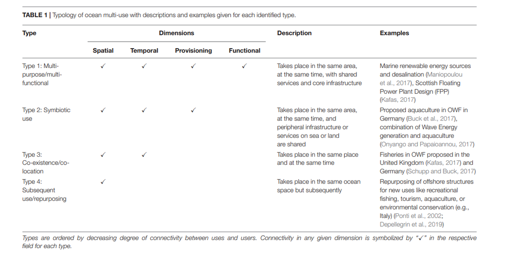

Types of multiple use in MSP according to [Schupp et al. 2019](https://doi.org/10.3389/fmars.2019.00165)